# PS5

Vivian Ouzounis

2023-02-18

# Loading and checking data

```r
library(tidyverse)
gapminder <- read_delim("../data/gapminder.csv.bz2")
```

**Load data. How many rows/columns do we have?**

There are 13055 rows and 25 columns

**Print a small sample of data. Does it look OK?**

```r
gapminder %>%
  sample_n(5)
```

```
## # A tibble: 5 × 25
##   iso3  name  iso2  region sub-r…¹ inter…²  time total…³ ferti…⁴ lifeE…⁵ child…⁶
##   <chr> <chr> <chr> <chr>  <chr>   <chr>   <dbl>   <dbl>   <dbl>   <dbl>   <dbl>
## 1 COD   Cong… CD    Africa Sub-Sa… Middle…  1999  4.59e7    6.76    49.6   164.
## 2 KOS   <NA>  <NA>  <NA>   <NA>    <NA>     1969  1.19e6   NA       NA      NA
## 3 DEU   Germ… DE    Europe Wester… <NA>     1986  7.77e7    1.43    74.3    10.6
## 4 BFA   Burk… BF    Africa Sub-Sa… Wester…  2014  1.76e7    5.52    59.4   104.
## 5 ARE   Unit… AE    Asia   Wester… <NA>     1965  1.50e5    6.84    56.5   149.
## # … with 14 more variables: youthFemaleLiteracy <dbl>, youthMaleLiteracy <dbl>,
## #   adultLiteracy <dbl>, GDP_PC <dbl>, accessElectricity <dbl>,
## #   agriculturalLand <dbl>, agricultureTractors <dbl>, cerealProduction <dbl>,
## #   fertilizerHa <dbl>, co2 <dbl>, greenhouseGases <dbl>, co2_PC <dbl>,
## #   pm2.5_35 <dbl>, battleDeaths <dbl>, and abbreviated variable names
## #   ¹`sub-region`, ²`intermediate-region`, ³totalPopulation, ⁴fertilityRate,
## #   ⁵lifeExpectancy, ⁶childMortality
```

Yes, the data looks OK

# Descriptive statistics

**1. How many countries are there in the dataset? Analyze all three: iso3, iso2 and name.**

```r
gapminder %>%
  summarise(names = n_distinct(iso3))
```

```
## # A tibble: 1 × 1
##   names
##   <int>
## 1   253
```

There are *253* countries in the iso3 column.

```r
gapminder %>%
  summarise(names = n_distinct(iso2))
```

```
## # A tibble: 1 × 1
##   names
##   <int>
## 1   249
```

There are *249* countries in the iso2 column.

```r
gapminder %>%
  summarise(names = n_distinct(name))
```

```
## # A tibble: 1 × 1
##   names
##   <int>
## 1   250
```

There are *250* countries in the names column.

**2. If you did this correctly, you saw that there are more names than iso-2 codes, and there are** **even more iso3-codes. What is going on? Can you find it?**

I believe it is because there are NA values in this dataframe that skew the numbers of iso2, iso3 and names.

**2(a). Find how many names are there for each iso-2 code. Are there any iso-2 codes that** **correspond to more than one name? What are these countries?**

```r
gapminder %>%
  group_by(name) %>%
  summarise(num = n_distinct(iso2)) %>%
  arrange(desc(num))
```

```
## # A tibble: 250 × 2
##    name                  num
##    <chr>               <int>
##  1 Afghanistan             1
##  2 Åland Islands           1
##  3 Albania                 1
##  4 Algeria                 1
##  5 American Samoa          1
##  6 Andorra                 1
##  7 Angola                  1
##  8 Anguilla                1
##  9 Antarctica              1
## 10 Antigua and Barbuda     1
## # … with 240 more rows
```

No iso2 numbers correspond to more than one name.

**2(b). Now repeat the same for name and iso3-code. Are there any country names that** **have more than one iso3-code? What are these countries? Hint: two of these entities** **are *CHANISL* and *NLD CURACAO***

```r
gapminder %>%
  group_by(name) %>%
  summarise(num = n_distinct(iso3)) %>%
  arrange(desc(num))
```

```
## # A tibble: 250 × 2
##    name             num
##    <chr>          <int>
##  1 <NA>               4
##  2 Afghanistan        1
##  3 Åland Islands      1
##  4 Albania            1
##  5 Algeria            1
##  6 American Samoa     1
##  7 Andorra            1
##  8 Angola             1
##  9 Anguilla           1
## 10 Antarctica         1
## # … with 240 more rows
```

**3. What is the minimum and maximum year in this data?**

```r
gapminder %>%
  filter(!is.na(time)) %>%
  summarize(min_year = min(time), max_year = max(time))
```

```
## # A tibble: 1 × 2
##   min_year max_year
##      <dbl>    <dbl>
## 1     1960     2019
```

The minimum year is 1960, and the maximum year is 2019.

# CO2 Emissions

**1. How many missing co2 emissions are there for each year? Analyse both missing *CO2* and *c02_PC*. Which years have most missing data?**

```r
gapminder %>%
  summarise(missing_count = sum(is.na(co2)))
```

```
## # A tibble: 1 × 1
##   missing_count
##           <int>
## 1          2658
```

For co2, there are *2658* missing co2 emissions.

```r
gapminder %>%
  summarise(missing_count = sum(is.na(co2_PC)))
```

```
## # A tibble: 1 × 1
##   missing_count
##           <int>
## 1          2661
```

For co2_PC, there are *2661* missing values.

```r
gapminder %>%
  group_by(time) %>%
  summarise(missing_count = sum(is.na(co2))) %>%
  arrange(desc(missing_count)) %>%
  head(5)
```

```
## # A tibble: 5 × 2
##    time missing_count
##   <dbl>         <int>
## 1  2017           217
## 2  2018           217
## 3  2019           217
## 4  1960            60
## 5  1961            60
```

```r
gapminder %>%
  group_by(time) %>%
  summarise(missing_count = sum(is.na(co2_PC))) %>%
  arrange(desc(missing_count)) %>%
  head(5)
```

```
## # A tibble: 5 × 2
##    time missing_count
##   <dbl>         <int>
## 1  2017           217
## 2  2018           217
## 3  2019           217
## 4  1960            60
## 5  1961            60
```

The years with the most missing data for both CO2 and CO2_PC are 2017, 2018, 2019, 1960, and 1961.

**2. Make a plot of total CO2 emissions over time for the U.S., China, and India. Add a few more countries of your choice. Explain what you see.**

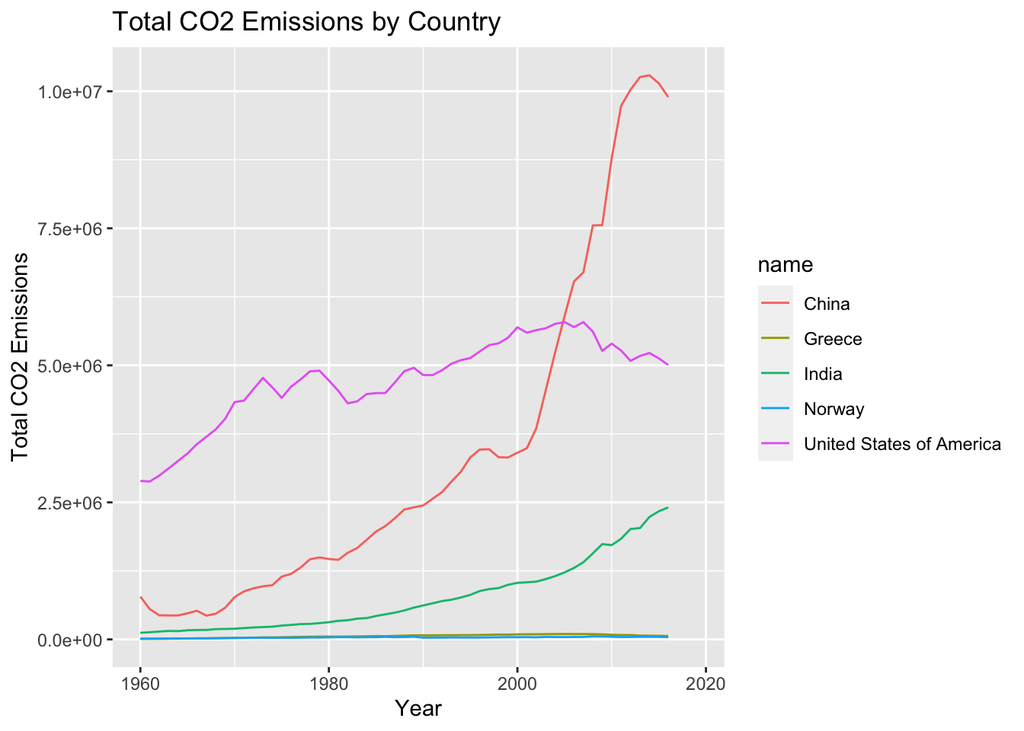

```r
countries <- c("United States of America", "China", "India", "Greece", "Norway")

data_filtered <- gapminder %>%
  filter(name %in% countries)

ggplot(data_filtered, aes(x = time, y = co2, color = name)) +
  geom_line() +
  labs(x = "Year", y = "Total CO2 Emissions",
       title = "Total CO2 Emissions by Country")
```

**3. Now let’s analyze the CO2 emissions per capita (*co2_PC*). Make a similar plot of the same countries. What does this figure suggest?**

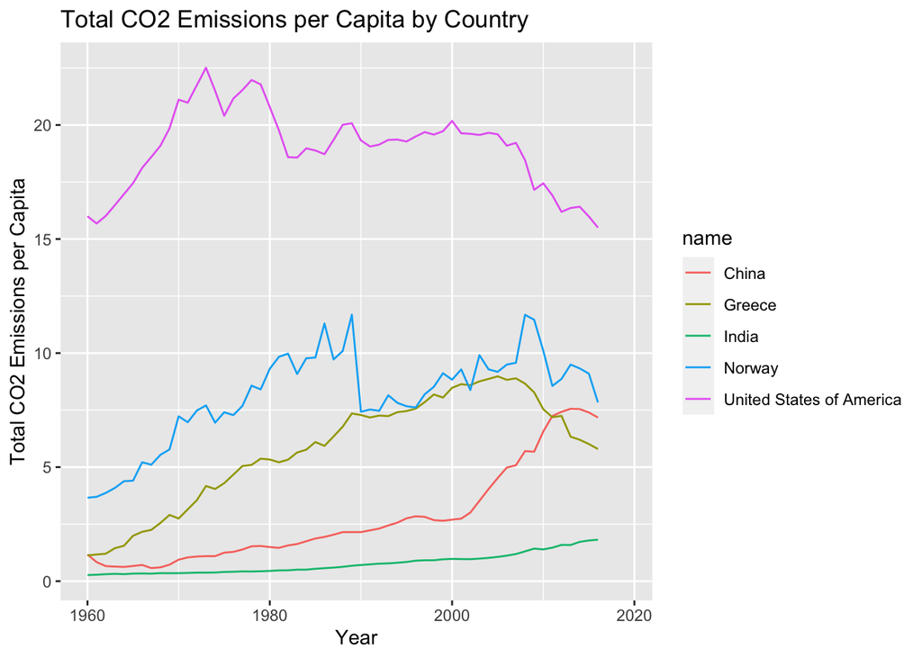

```r
countries <- c("United States of America", "China", "India", "Greece", "Norway")

data_filtered <- gapminder %>%
  filter(name %in% countries)

ggplot(data_filtered, aes(x = time, y = co2_PC, color = name)) +
  geom_line() +
  labs(x = "Year", y = "Total CO2 Emissions per Capita",
       title = "Total CO2 Emissions per Capita by Country")
```

When looking at per capita emissions, the U.S. has *much* more CO2 emissions compared to the other four countries displayed. Norway has the second highest (a big difference from the previous graph), with Greece beginning to reach similar levels in the 1990s. India has the lowest CO2 emissions per capita. This shows how important it is to take population into account for emission comparisons.

**4. Compute average CO2 emissions per capita across the continents (assume region is the same as continent). Comment what do you see.**

```r
gapminder %>%
  group_by(region) %>%
  summarise(avg_co2_PC = mean(co2_PC, na.rm = TRUE)) %>%
  arrange(desc(avg_co2_PC)) %>%
  tail(5)
```

```
## # A tibble: 5 × 2
##   region   avg_co2_PC
##   <chr>         <dbl>
## 1 Europe        7.95
## 2 Americas      6.46
## 3 Asia          6.21
## 4 Oceania       4.39
## 5 Africa        0.930
```

This shows that Europe has the highest average CO2 emissions per capita, while Africa has the lowest. The America’s have the second highest, which is a very similar number to the third highest which is Asia.

**5. Make a barplot where you show the previous results - average CO2 emissions per capita across continents in 1960 and 2016.**

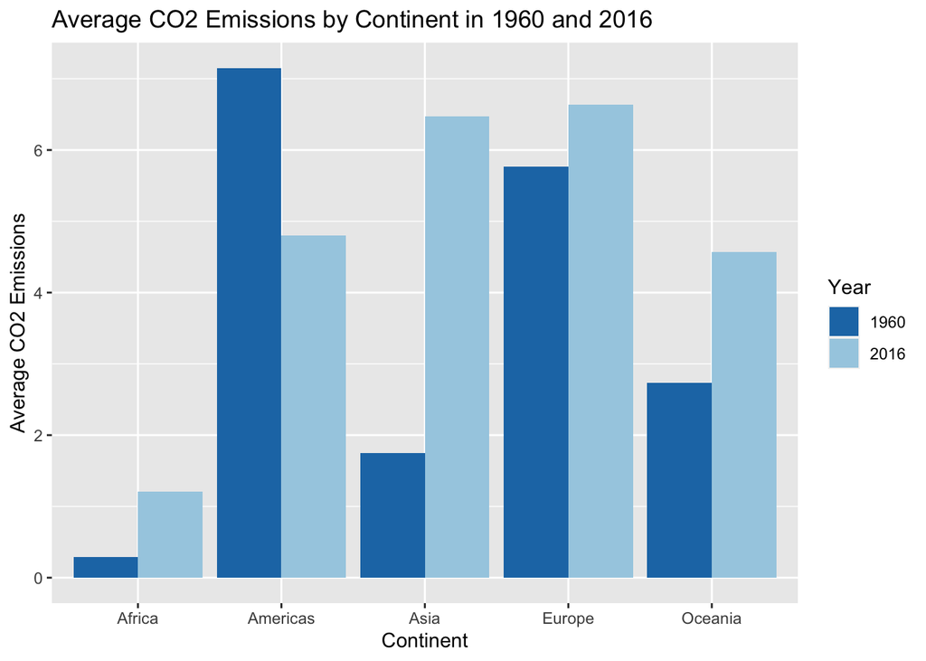

```r
# Filter data for 1960 and 2016
data_filtered <- gapminder %>%
  filter(time %in% c(1960, 2016)) %>%
  filter(!is.na(region))

avg_co2_PC <- data_filtered %>%
  group_by(time, region) %>%
  summarise(avg_co2_PC = mean(co2_PC, na.rm = TRUE))

ggplot(avg_co2_PC, aes(x = region, y = avg_co2_PC, fill = factor(time))) +
  geom_bar(stat = "identity", position = "dodge") +
  labs(x = "Continent", y = "Average CO2 Emissions",
       title = "Average CO2 Emissions by Continent in 1960 and 2016") +
  scale_fill_manual(values = c("#1f78b4", "#a6cee3"),
                    name = "Year", labels = c("1960", "2016"))
```

**6. Which countries are the three largest, and three smallest CO2 emitters (in terms of CO2 per capita) in 2019 for each continent?**

```r
gapminder %>%
  filter(time == "2019" & (!is.na(region))) %>%
  group_by(region) %>%
  arrange(co2_PC) %>%
  slice_head(n = 3) %>%
  select(region, name)
```

```
## # A tibble: 15 × 2
## # Groups:   region [5]
##    region   name
##    <chr>    <chr>
##  1 Africa   Angola
##  2 Africa   Burundi
##  3 Africa   Benin
##  4 Americas Aruba
##  5 Americas Argentina
##  6 Americas Antigua and Barbuda
##  7 Asia     Afghanistan
##  8 Asia     United Arab Emirates
##  9 Asia     Armenia
## 10 Europe   Albania
## 11 Europe   Andorra
## 12 Europe   Austria
## 13 Oceania  American Samoa
## 14 Oceania  Australia
## 15 Oceania  Fiji
```

```r
gapminder %>%
  filter(time == "2019" & (!is.na(region))) %>%
  group_by(region) %>%
  arrange(co2_PC) %>%
  slice_tail(n = 3) %>%
  select(region, name)
```

```
## # A tibble: 15 × 2
## # Groups:   region [5]
##    region   name
##    <chr>    <chr>
##  1 Africa   South Africa
##  2 Africa   Zambia
##  3 Africa   Zimbabwe
##  4 Americas Venezuela (Bolivarian Republic of)
##  5 Americas Virgin Islands (British)
##  6 Americas Virgin Islands (U.S.)
##  7 Asia     Uzbekistan
##  8 Asia     Viet Nam
##  9 Asia     Yemen
## 10 Europe   Slovenia
## 11 Europe   Sweden
## 12 Europe   Ukraine
## 13 Oceania  Tuvalu
## 14 Oceania  Vanuatu
## 15 Oceania  Samoa
```

# GDP per capita

**1. Make a scatterplot of GDP per capita versus life expectancy by country, using data for 1960.** **Make the point size dependent on the country size, and color those according to the continent.** **Comment what you see there.**

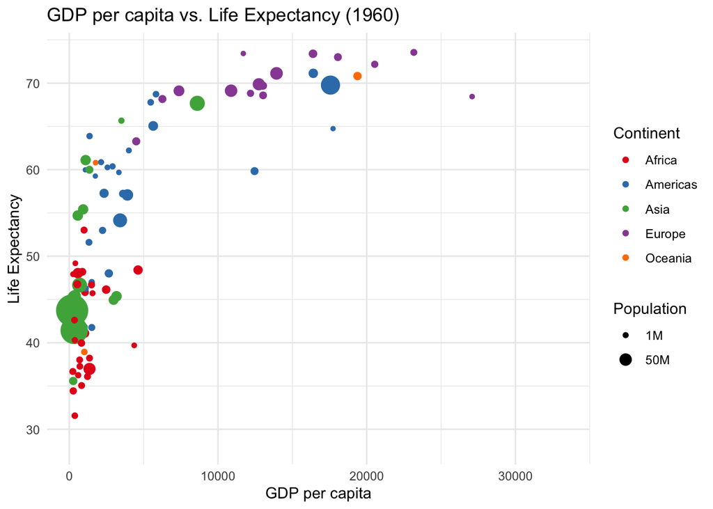

```r
data_1960 <- gapminder %>%
  filter(time == 1960 &(!is.na(region)))

ggplot(data_1960, aes(x = GDP_PC, y = lifeExpectancy)) +
  geom_point(aes(size = totalPopulation, color = region)) +
  scale_color_brewer(palette = "Set1") +
  scale_size_continuous(range = c(1,10), breaks = c(1e6, 5e7, 1e9), labels = c("1M", "50M", "1B")) +
  labs(title = "GDP per capita vs. Life Expectancy (1960)",
       x = "GDP per capita",
       y = "Life Expectancy",
       size = "Population",
       color = "Continent") +
  theme_minimal()
```

**2. Make a similar plot, but this time use 2019 data only.**

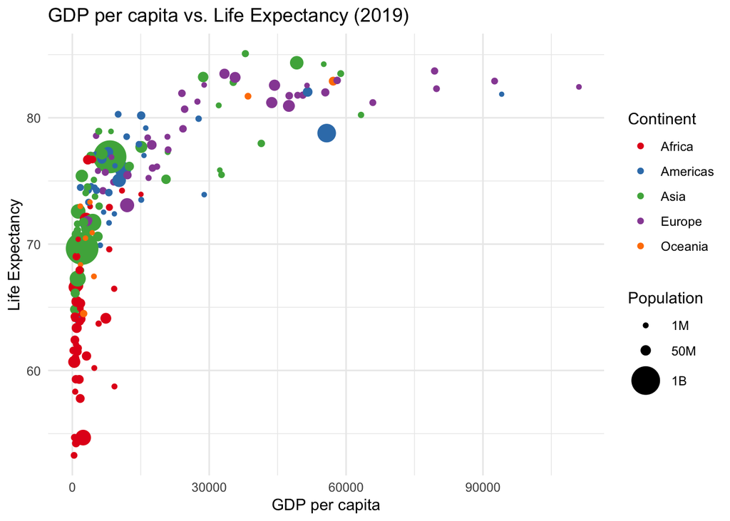

```r
data_2019 <- gapminder %>%
  filter(time == 2019 &(!is.na(region)))

ggplot(data_2019, aes(x = GDP_PC, y = lifeExpectancy)) +
  geom_point(aes(size = totalPopulation, color = region)) +
  scale_color_brewer(palette = "Set1") +
  scale_size_continuous(range = c(1,10), breaks = c(1e6, 5e7, 1e9), labels = c("1M", "50M", "1B")) +
  labs(title = "GDP per capita vs. Life Expectancy (2019)",
       x = "GDP per capita",
       y = "Life Expectancy",
       size = "Population",
       color = "Continent") +
  theme_minimal()
```

**3. (6pt) Compare these two plots and comment what do you see. How has world developed** **through the last 60 years?**

Africa has grown in population and life expectancy has increased, however GDP per capita has not grown. Asia has seen some GDP and population growth (with some countries comparable to Europe and the Americas), and a definite increase in life expectancy. Europe’s GDP per capita has grown, and so has life expectancy. The America’s have also seen growth in GDP and life expectancy. Overall, the population has grown a significant amount.

**4. Compute the average life expectancy for each continent in 1960 and 2019. Do the results** **fit with what do you see on the figures?**

```r
life_exp_1960 <- gapminder %>%
  filter(time == 1960 & (!is.na(region))) %>%
  group_by(region) %>%
  summarize(avg_life_exp = mean(lifeExpectancy, na.rm = TRUE)) %>%
  arrange(desc(avg_life_exp))
life_exp_1960
```

```
## # A tibble: 5 × 2
##   region   avg_life_exp
##   <chr>           <dbl>
## 1 Europe           68.3
## 2 Americas         58.6
## 3 Oceania          56.4
## 4 Asia             51.6
## 5 Africa           41.5
```

```r
life_exp_2019 <- gapminder %>%
  filter(time == 2019 & (!is.na(region))) %>%
  group_by(region) %>%
  summarize(avg_life_exp = mean(lifeExpectancy, na.rm = TRUE)) %>%
  arrange(desc(avg_life_exp))
life_exp_2019
```

```
## # A tibble: 5 × 2
##   region   avg_life_exp
##   <chr>           <dbl>
## 1 Europe           79.4
## 2 Americas         75.8
## 3 Asia             74.6
## 4 Oceania          73.5
## 5 Africa           64.1
```

Yes, the results fit with what I see on the figures. Europe and the America’s have the highest life expectancy, with all countries increasing between the two dates.

**5. Compute the average LE growth from 1960-2019 across the continents. Show the results** **in the order of growth. Explain what do you see.**

```r
life_exp_growth <- gapminder %>%
  filter(time %in% c(1960, 2019)) %>%
  filter(!is.na(lifeExpectancy)) %>%
  group_by(region) %>%
  summarize(avg_growth = mean(lifeExpectancy[time == 2019]) - mean(lifeExpectancy[time == 1960]))

life_exp_growth %>%
  arrange(desc(avg_growth)) %>%
  head(5)
```

```
## # A tibble: 5 × 2
##   region   avg_growth
##   <chr>         <dbl>
## 1 Asia           23.0
## 2 Africa         22.6
## 3 Americas       17.2
## 4 Oceania        17.1
## 5 Europe         11.1
```

Asia has experienced the most avg. LE growth from 1960 to 2019. Africa has increased the second most, and Europe has increased the least. This is due to rapid development in Africa and Asia.

**6. Show the histogram of GDP per capita for years of 1960 and 2019. Try to put both** **histograms on the same graph, see how well you can do it!**

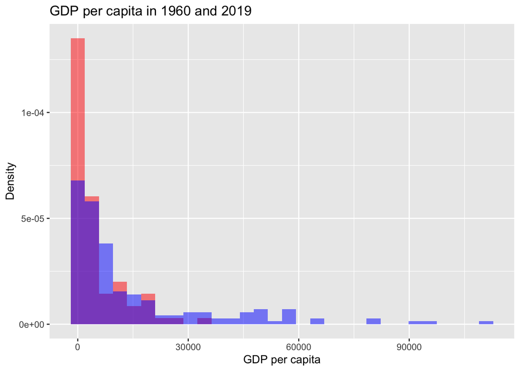

```r
gdp_df <- gapminder %>%
  filter(time %in% c(1960, 2019)) %>%
  select(name, time, GDP_PC)

hist_1960 <- ggplot(gdp_df %>% filter(time == 1960), aes(x = GDP_PC)) +
  geom_histogram(aes(y = ..density..), alpha = 0.5, fill = "red") +
  ggtitle("GDP per capita in 1960 and 2019") +
  xlab("GDP per capita") + ylab("Density")

hist_2019 <- ggplot(gdp_df %>% filter(time == 2019), aes(x = GDP_PC)) +
  geom_histogram(aes(y = ..density..), alpha = 0.5, fill = "blue") +
  ggtitle("GDP per capita in 1960 and 2019") +
  xlab("GDP per capita") + ylab("Density")

combined_hist <- hist_1960 +
  geom_histogram(data = gdp_df %>% filter(time == 2019), aes(x = GDP_PC, y = ..density..), alpha = 0.5, fill = "blue")

combined_hist
```

**7. What was the ranking of US in terms of life expectancy in 1960 and in 2019? (When** **counting from top.)**

```r
life_exp_df <- gapminder %>%
  filter(time %in% c(1960, 2019)) %>%
  filter(!is.na(region)) %>%
  select(name, time, lifeExpectancy)

ranked_df <- life_exp_df %>%
  group_by(time) %>%
  mutate(rank = rank(-lifeExpectancy))

us_df <- ranked_df %>%
  filter(name == "United States of America")

cat("Rank of US in 1960:", us_df$rank[us_df$time == 1960], "\n")
```

```
## Rank of US in 1960: 17
```

```r
cat("Rank of US in 2019:", us_df$rank[us_df$time == 2019], "\n")
```

```
## Rank of US in 2019: 46
```

**8. If you did this correctly, then you noticed that US ranking has been falling quite a** **bit. But we also have more countries in 2019–what about the relative rank divided by the** **corresponding number of countries that have LE data in the corresponding year?**

```r
life_exp_df <- gapminder %>%
  filter(time %in% c(1960, 2019)) %>%
  filter(!is.na(region)) %>%
  select(name, time, lifeExpectancy)

n_countries <- life_exp_df %>%
  group_by(time) %>%
  summarize(n_countries = n())

life_exp_df <- life_exp_df %>%
  left_join(n_countries)
ranked_df <- life_exp_df %>%
  group_by(time) %>%
  mutate(rank = rank(-lifeExpectancy))

us_df <- ranked_df %>%
  filter(name == "United States of America")

relative_rank <- us_df %>%
  mutate(relative_rank = rank / n_countries)

cat("Relative rank of US in 1960:", relative_rank$relative_rank[relative_rank$time == 1960], "\n")
```

```
## Relative rank of US in 1960: 0.08018868
```

```r
cat("Relative rank of US in 2019:", relative_rank$relative_rank[relative_rank$time == 2019], "\n")
```

```
## Relative rank of US in 2019: 0.2159624
```